# Loans Data Explanation

## Dataset Overview

The `Loans dataset` contains 113,937 loans since 2005/2014 with 81 variables on each loan, including loan amount, current loan status, borrower income, borrower occupation, and many others.  
It's contains qualititave varibles such as loan status, loan category, borrower state and occupation and others. Also, it's contains quantitave variables such as loan amount, term, borrower income and others.

## Investigation Overview

In this investigation, I want to look what factors of difference columns (borrower income, occupation, state, etc.) that affect on loans outcome.

## Loans Status Frequencies

The following chart illustrates the most loans status exists in the dataset.

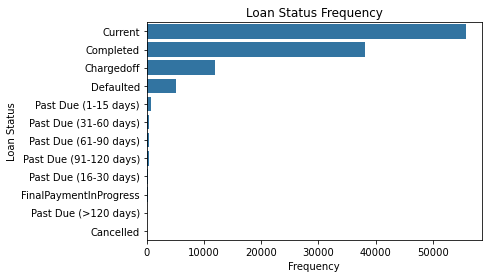

## Loans Categories Frequencies

The following chart illustrates the most loans category exists in the dataset.

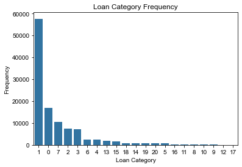

> The category of the listing that the borrower selected when posting their listing:  
> 0 - Not Available, 1 - Debt Consolidation, 2 - Home Improvement, 3 - Business, 4 - Personal Loan, 5 - Student Use, 6 - Auto, 7- Other, 8 - Baby&Adoption, 9 - Boat, 10 - Cosmetic Procedure, 11 - Engagement Ring, 12 - Green Loans, 13 - Household Expenses, 14 - Large Purchases, 15 - Medical/Dental, 16 - Motorcycle, 17 - RV, 18 - Taxes, 19 - Vacation, 20 - Wedding Loans

## Borrowers State Proportion

The following chart illustrates the most borrowers state exists in the dataset.

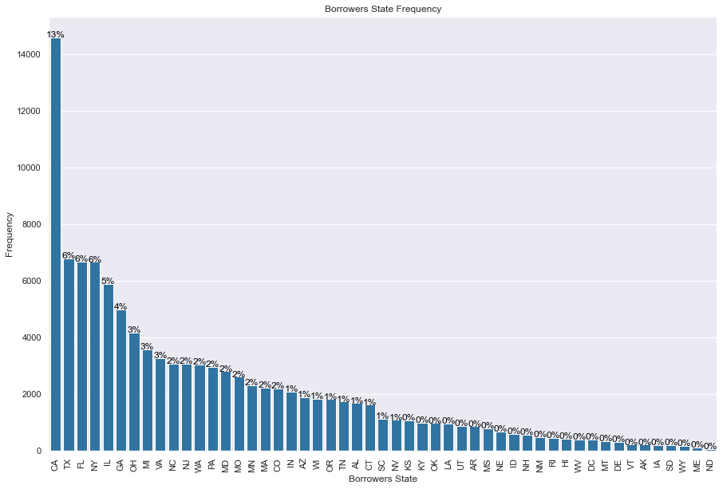

## Borrowers Occupation Frequencies

The following chart illustrates the most borrowers occupation exists in the dataset.

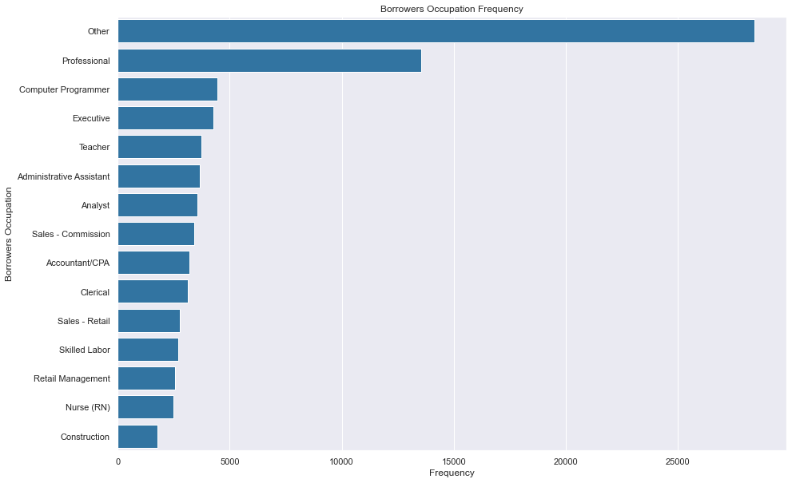

## Borrowers Own Home

The following chart illustrates the borrowers they own home exists in the dataset.

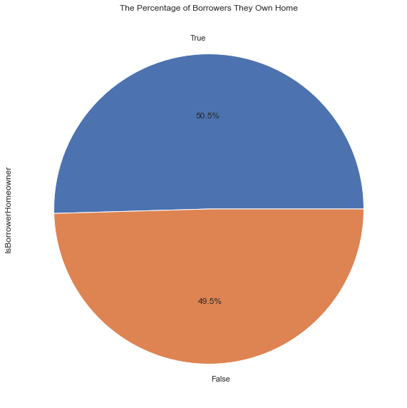

## Loans Amount Frequencies

The following chart illustrates the most loans amount frequencies exists in the dataset.

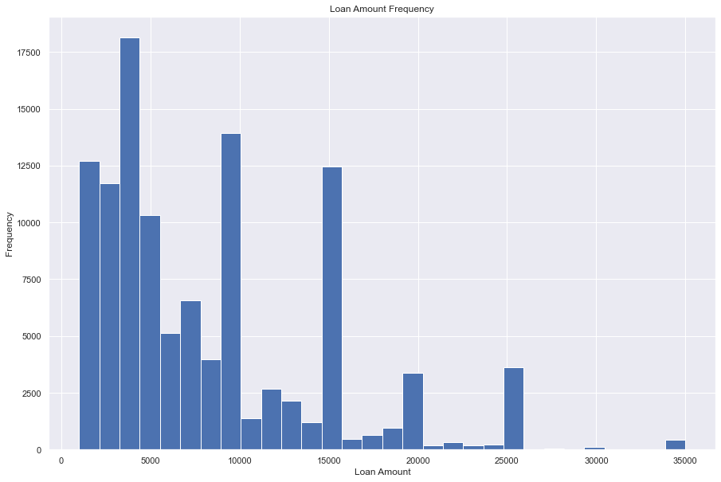

## Relation Between Loan Amount and Borrower Income

The following chart illustrates the relation between quantitative vs. quantitative variables useing scatter plot for exploring loan amount and borrower income.  
Regarding to the correlation coefficient between them which is equal to 0.2, there is positive and weak relationship.

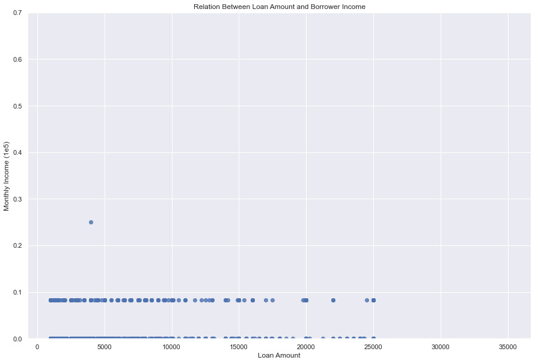

## Relation Between Loan Status and Rest Monthly Payment

The following chart illustrates the relation between quantitative vs. qualitative variables using violin plot for exploring the relation between borrower they are losing thier occupation before completing loan payments and loan status.

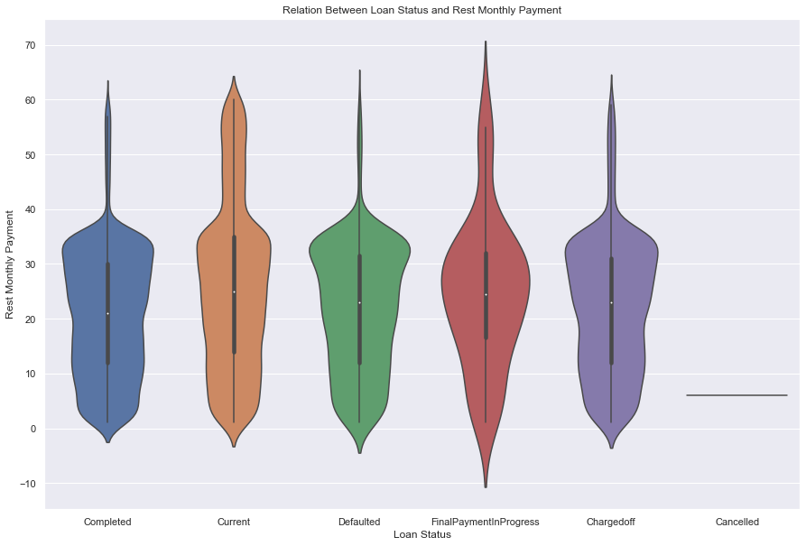

## Relation Between Income Range and The Payment Months of Loan

The following chart illustrates the relation between income range and the payment months of loan.

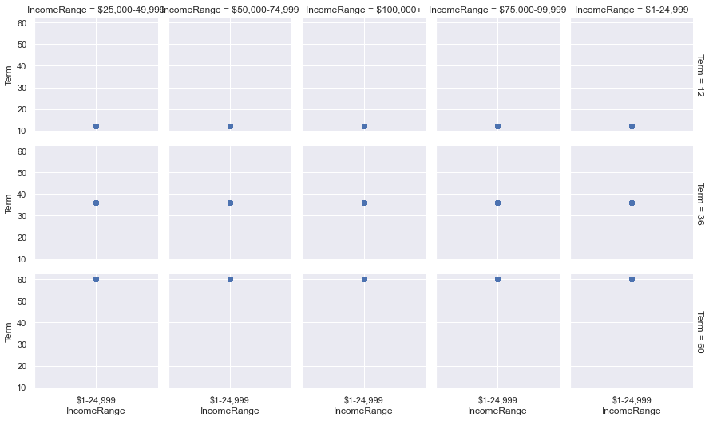

## Relation Between Total Prosper Loans and Payment Status

The following chart illustrates the relation between number of prosper loans and payment status, either on time, late less a month or late plus a month. With each other loan for a borrower, the payment status is tend to late.

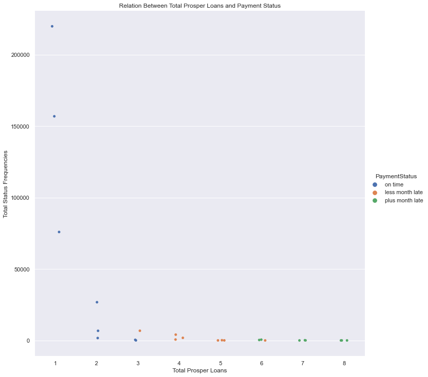